# PA1_template

Ekaterina Voronina

7/21/2020

Loading library to work with

```r
library(tidyverse)
```

Downloading data

```r
 url <- "https://d396qusza40orc.cloudfront.net/repdata%2Fdata%2Factivity.zip"
download.file(url,"repdata_data_activity.zip")
unzip("repdata_data_activity.zip")
```

Reading data and removing missing values

```r
data <- read.csv("activity.csv",header = TRUE, sep = ",")
data$date <- as.Date(data$date)
clean_data <- data[!is.na(data$steps), ]
```

Filtering data by date and calculating steps sum by day, changing column name

```r
sum_steps <- clean_data %>% group_by(date) %>% summarise(sum(steps))
names(sum_steps)[2] <- "steps"
```

Building histogram of total number of steps taken each day

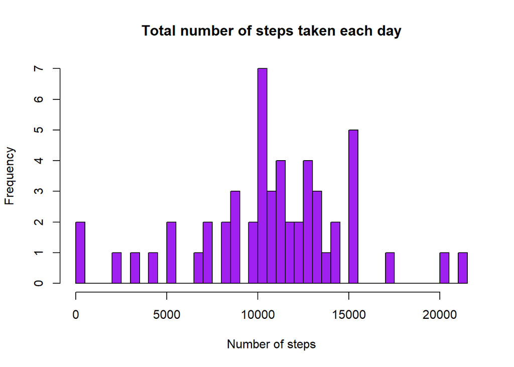

```r
hist(sum_steps$steps, col = "purple", main = "Total number of steps taken each day",
     xlab = "Number of steps", breaks = 40)
```

Usuing summary function to calculate “mean and”median" of the total number of steps taken per day

```r
summary(sum_steps$steps)
```

```
##    Min. 1st Qu.  Median    Mean 3rd Qu.    Max.
##      41    8841   10765   10766   13294   21194
```

Saving the histogram

```r
dev.copy(png,'steps.png', width=480, height=480)
```

```r
dev.off()
```

```r
average_steps <- clean_data %>% group_by(interval) %>% summarise(mean(steps))
names(average_steps)[2] <- "mean_steps"
```

Building the plot showing average number of steps taken across all days

```r
mean_steps_plot <-ggplot(average_steps, aes(x = interval,y = mean_steps)) + geom_line(color = "purple") +
  labs(title="Average number of steps taken across all days",
       y="Average number of steps", x="5-min Interval time series")
```

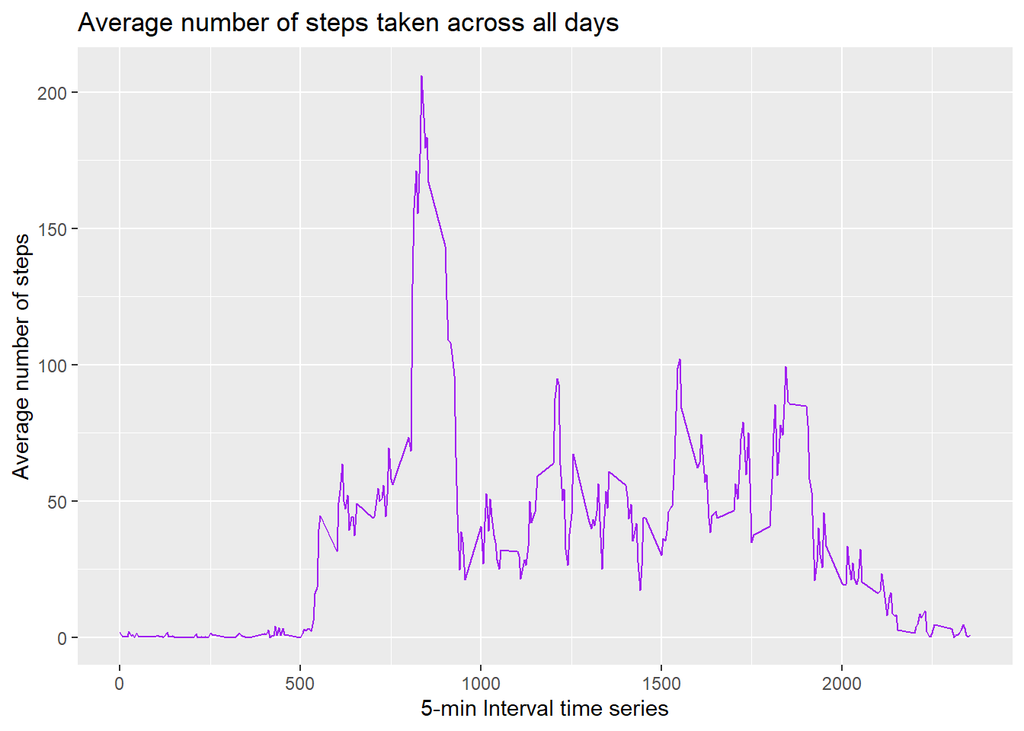

```r
show(mean_steps_plot)
```

Saving the plot

```r
dev.copy(png,'averagesteps.png', width=480, height=480)
```

```r
dev.off()
```

```r
which.max(average_steps$interval)
```

```
## [1] 288
```

```r
print(average_steps[104,])
```

```
## # A tibble: 1 x 2
##   interval mean_steps
##      <int>      <dbl>
## 1      835       206.
```

Calculating and the total number of missing values in the dataset

```r
sum(is.na(data))
```

```
## [1] 2304
```

The number of rows with NAs is 2304

Writting a fuccion to impute missing values

```r
mean_step <- clean_data %>% group_by(date) %>% summarise(mean(steps))

for(i in 1:length(data$steps)){
  if(is.na(data[i, "steps"])){

    for(y in 1:length(mean_step$date)){

      if(mean_step$date[y] == data$date[i]){
        data$steps[i] <- mean_step$`mean(steps)`[y]
      }

    }

  }
}


names(mean_step)[2] <- "steps"
```

[figure not shown]

```r
hist(mean_step$steps, col = "green", main = "Total number of steps taken each day",
     xlab = "Number of steps", breaks = 40)
```

Saving the histogram

```r
dev.copy(png,'na.png', width=480, height=480)
```

```r
dev.off()
```

Calculating mean and the median using summary function

```r
summary(mean_step$steps)
```

```
##    Min. 1st Qu.  Median    Mean 3rd Qu.    Max.
##  0.1424 30.6979 37.3785 37.3826 46.1597 73.5903
```

Creating a new variable including information about a weekday

```r
clean_data$day <- ifelse(weekdays(clean_data$date) %in% c("Saturday","Sunday"),
                         "weekday", "weekend")
```

Sorting the data to make a plot

```r
by_weekday <- clean_data %>% group_by(interval,day) %>% summarise(mean_step=mean(steps))
```

Making a panel plot showing time series

```r
plot_weekday <- ggplot(by_weekday, aes(x=interval, y=mean_step, color=day)) +
  facet_grid(day~.) + geom_line() +
  labs(title="Average Number of Steps Taken vs 5-min Interval on Weekday/Weekend",
       y="Average Number of Steps", x="5-min Interval Times Series")
```

[figure not shown]

```r
show(plot_weekday)
```

Saving a plot

```r
dev.copy(png,'timeseries.png', width=480, height=480)
```

```r
dev.off()
```